# EDA on Client Drone Data for Rust and Paint Crack Detection

## Introduction

This notebook presents an Exploratory Data Analysis (EDA) on a sample of drone-acquired data provided by the client, with the goal of detecting surface-level defects such as rust, paint cracks, and other anomalies on buildings.

This EDA aims to:

- Understand the nature and variety of the client's image data
- Experiment with self-supervised clustering, manual labeling and .laz files
- Assess if the data is suitable for rust/paint/crack detection

Insights from this notebook will help shape the next steps in model training and data preparation for the defect detection pipeline.

## Data Overview

The dataset used in this analysis was provided by the client and consists of two primary data types:

- Drone Images (RGB): High-resolution photographs taken from drones, capturing various surfaces of buildings. These are crucial for detecting small-scale defects such as rust or paint cracks.
- LiDAR Point Clouds (LAZ files): 3D spatial data representing the structure of the buildings. While useful for large-scale geometry, they are less effective for detecting fine-grained surface-level anomalies.

## Data Collection

All data is gotten from the client's cloud environment. Due to restrictions, the images could not be downloaded in bulk. For this EDA, one drone mission was selected and around 50 images were downloaded. Not all missions on the cloud are suitable for our problem as they contain nature rather than buildings. The images are not labelled.

The other available data on the client's cloud consists of LiDAR scans in a .laz format. These are 3D files.

## Data Requirements

For this project, we need real images that are labelled with bounding boxes or segmentation where there is rust or paint/cracks.

## Exploratory Data Analaysis (EDA)

Now, we are going to explore the images, see what we can do and make some conclusions whether they are going to be useful for our problem or not. It is important to not that whatever the outcome is, these images will always be suitable for validation data.

```python
import matplotlib.pyplot as plt
import cv2
import os
import glob
import random
import open3d as o3d
import laspy
import numpy as np
from IPython.display import Image, display
import plotly.express as px
import torch
import torchvision.transforms as T
from torchvision import datasets, models
from torch.utils.data import DataLoader
from sklearn.cluster import KMeans
from sklearn.decomposition import PCA
```

### Image Previews

We can see the drone images from this mission contain some buildings, which could be helpful in our task. The images are from far away and small details are not as visible, but this is to be expected with drone images. The issue that lies here is that they are not labeled. All the missions available were not directed to our task, so rust and paint/cracks are not the focus at all.

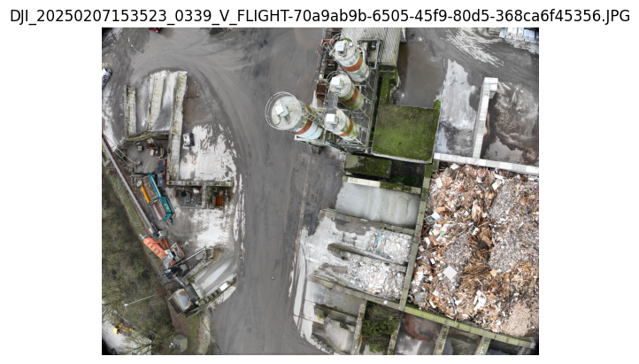

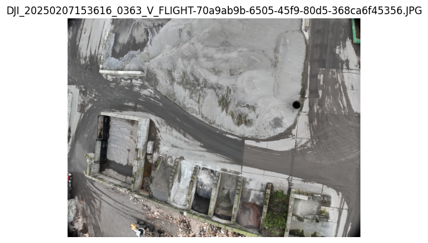

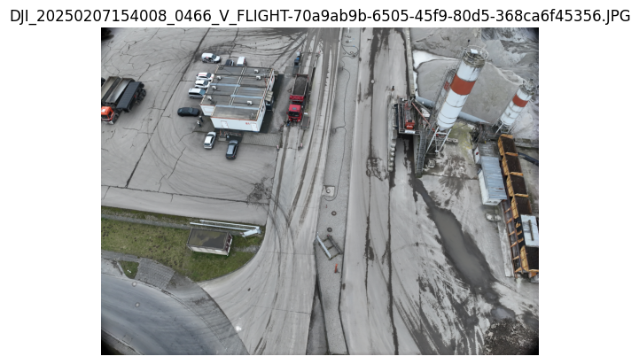

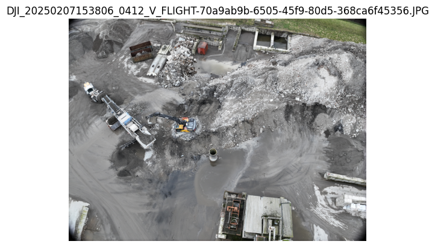

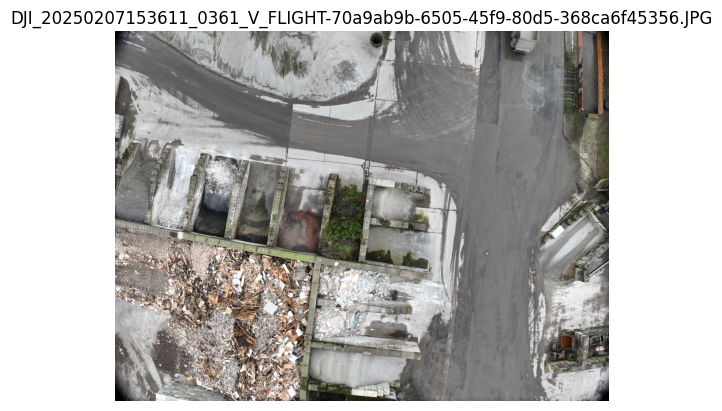

```python
image_paths = glob.glob("data/dummy/*.JPG")

sample_paths = random.sample(image_paths, min(5, len(image_paths)))

for path in sample_paths:
    img = cv2.imread(path)
    if img is not None:
        img = cv2.cvtColor(img, cv2.COLOR_BGR2RGB)
        plt.imshow(img)
        plt.title(os.path.basename(path))
        plt.axis('off')
        plt.show()
    else:
        print(f"Could not read image: {path}")
```

We can spot on these images some rust and paint/cracks in the towers for example, so they can be used in our problem.

### Self-Supervised Learning

To explore patterns in the client's drone image data without relying on labels, we apply self-supervised learning—a method where the model learns to recognize useful visual features by comparing different augmented views of the same image. Using a modified ResNet-18, we train the network to produce similar outputs for original and flipped versions of each image. These learned embeddings are then clustered with KMeans and visualized using PCA, helping us group visually similar surfaces (e.g., rusted areas, clean walls) and uncover structure in the dataset without manual annotation.

The code below is a really simple self-supervised learning without many needed installations to test it out. As already mentioned, we cannot get a bulk of images from the cloud, so around 50 images were downloaded to try this method.

```
Epoch 1 - Loss: 0.0156
Epoch 2 - Loss: 0.0052
Epoch 3 - Loss: 0.0032
```

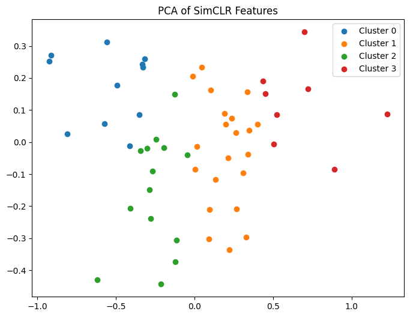

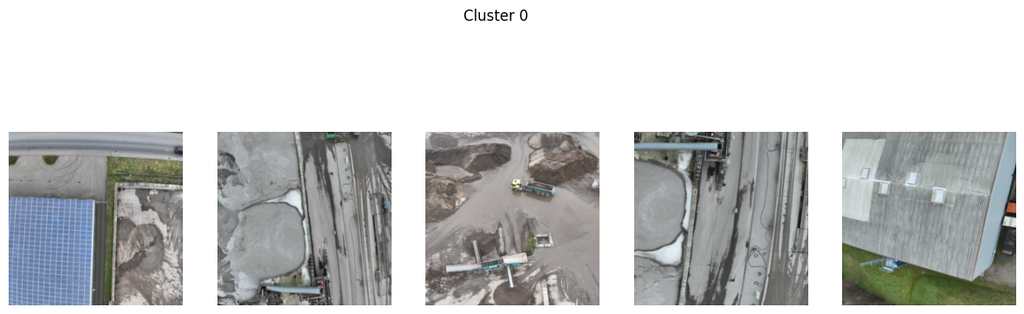

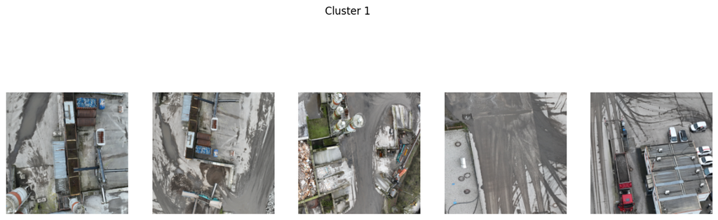

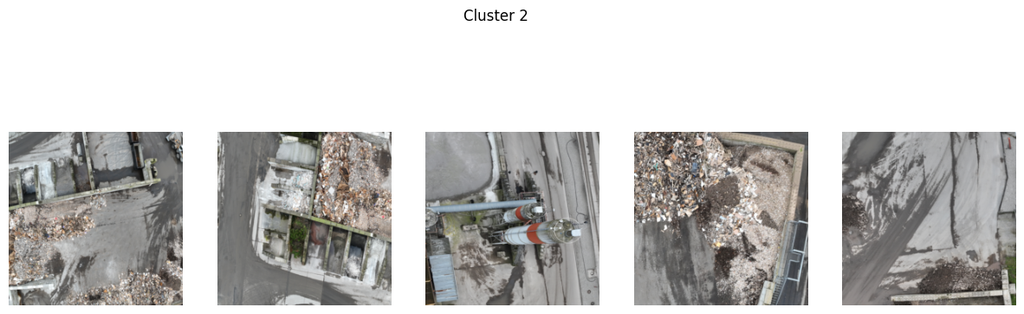

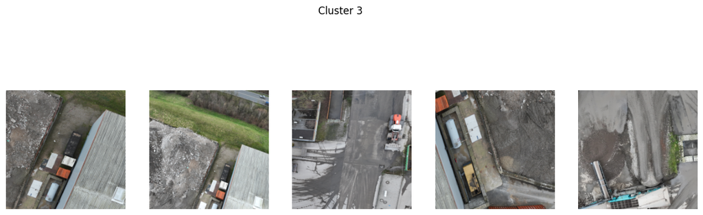

```python
transform = T.Compose([
    T.RandomResizedCrop(224),
    T.RandomHorizontalFlip(),
    T.ToTensor()
])

dataset = datasets.ImageFolder(root='data', transform=transform)
loader = DataLoader(dataset, batch_size=16, shuffle=True)

encoder = models.resnet18(pretrained=False)
encoder.fc = torch.nn.Identity()

def train_encoder(encoder, loader, epochs=3):
    optimizer = torch.optim.Adam(encoder.parameters(), lr=1e-3)
    loss_fn = torch.nn.MSELoss()

    encoder.train()
    for epoch in range(epochs):
        for x, _ in loader:
            x1 = x
            x2 = x1.flip(-1)
            z1 = encoder(x1)
            z2 = encoder(x2)
            loss = loss_fn(z1, z2)
            optimizer.zero_grad()
            loss.backward()
            optimizer.step()
        print(f"Epoch {epoch+1} - Loss: {loss.item():.4f}")

train_encoder(encoder, loader)

encoder.eval()
all_embeddings = []
all_images = []

with torch.no_grad():
    for x, _ in loader:
        emb = encoder(x).numpy()
        all_embeddings.append(emb)
        all_images.extend(x)

embeddings = np.vstack(all_embeddings)

kmeans = KMeans(n_clusters=4)
labels = kmeans.fit_predict(embeddings)

pca = PCA(n_components=2)
proj = pca.fit_transform(embeddings)

plt.figure(figsize=(8, 6))
for i in range(4):
    idxs = np.where(labels == i)[0]
    plt.scatter(proj[idxs, 0], proj[idxs, 1], label=f"Cluster {i}")
plt.legend()
plt.title("PCA of SimCLR Features")
plt.show()

def show_cluster_images(images, labels, cluster_id, max_imgs=5):
    idxs = [i for i, l in enumerate(labels) if l == cluster_id]
    fig, axes = plt.subplots(1, min(max_imgs, len(idxs)), figsize=(15, 5))
    for i, ax in enumerate(axes):
        img = images[idxs[i]].permute(1, 2, 0).numpy()
        ax.imshow(img)
        ax.axis("off")
    plt.suptitle(f"Cluster {cluster_id}")
    plt.show()

for i in range(4):
    show_cluster_images(all_images, labels, i)
```

After training a simple self-supervised encoder on the drone image dataset, we extracted embeddings for each image and applied KMeans clustering to group them into 4 clusters. We then used PCA to reduce the high-dimensional embeddings to 2D and plotted them for visual inspection.

The PCA plot shows that the learned features separate the images into distinct clusters, suggesting the encoder captured meaningful patterns even without labels.

- Cluster 0 appears to contain mostly construction zones or sandy/dirty ground surfaces.
- Cluster 1 includes large flat industrial surfaces like roads and parking lots, often with vehicle traces.
- Cluster 2 groups areas with dense clutter, such as trash piles, debris, or industrial structures.
- Cluster 3 shows cleaner outdoor zones, rooftops, and larger open surfaces, possibly indicating clearer areas.

These results demonstrate that even a basic self-supervised setup can help organize unlabeled drone data, providing a strong foundation for later tasks like anomaly detection or pre-labeling. It also highlights the potential to detect outlier surface types (e.g., rust-prone zones or areas with unusual textures) through clustering without needing manual annotations at this stage.

The clusters are indeed not perfect, but we can see there is some similarity between the photos in the cluster. This method could be useful if we have more images at hand to actually make better clusters that could be useful. It does not even need to be a cluster rust, paint and cracks. If we were able to get a bulk of images from multiple missions, we can run the self-supervised learning and maybe get a cluster that contains only building, which would definetely help in our task, but then it will be needed manual labeling for that cluster or to run again a self-supervised clustering on that cluster to get different groups on the buildings.

### Manual Labeling with Roboflow

To continue with the data exploration, we tried manual labeling with Roboflow. I created a dataset in Roboflow and uploaded some pictures and tried manual labeling. I would not say this is a very trustworthy method as I am not even sure I am labeling correctly. The images are taken from far away so it is really hard to zoom in and notice details such as small rust patches. However, it was tried to do so and then the dataset was exported in YOLO format. Here, an image is plotted based on the export with the labels in YOLO format.

```python
img_dir = os.path.join("yolo", "valid", "images")
label_dir = os.path.join("yolo", "valid", "labels")

img_files = [f for f in os.listdir(img_dir) if f.endswith(('.jpg', '.png'))]
label_files = [f for f in os.listdir(label_dir) if f.endswith('.txt')]

img_path = os.path.join(img_dir, img_files[0])
label_path = os.path.join(label_dir, label_files[0])

img = cv2.imread(img_path)
img = cv2.cvtColor(img, cv2.COLOR_BGR2RGB)
h, w, _ = img.shape

class_colors = {
    0: (255, 0, 0),
    1: (0, 255, 0)
    }

fig = px.imshow(image_rgb)
fig.update_layout(title="YOLO Bounding Box Visualization")

used_classes = set()

with open(label_path, 'r') as f:
    lines = f.readlines()

for line in lines:
    parts = line.strip().split()
    class_id, x_center, y_center, bw, bh = map(float, parts)
    class_id = int(class_id)

    x_center *= w
    y_center *= h
    bw *= w
    bh *= h

    x1 = x_center - bw / 2
    y1 = y_center - bh / 2
    x2 = x_center + bw / 2
    y2 = y_center + bh / 2

    color = class_colors.get(class_id, (255, 0, 0))
    color_str = f"rgb{color}"

    fig.add_shape(
        type="rect",
        x0=x1, y0=y1, x1=x2, y1=y2,
        line=dict(color=color_str, width=3),
        layer="above"
    )
fig.update_yaxes(autorange="reversed")
fig.update_layout(
    title="YOLO Bounding Box Visualization",
    margin=dict(l=40, r=40, t=60, b=40),
    autosize=True,
    width=image_rgb.shape[1] + 80,
    height=image_rgb.shape[0] + 100,
    plot_bgcolor='white',
    paper_bgcolor='white',
)
fig.update_xaxes(showticklabels=False)
fig.update_yaxes(showticklabels=False)
fig.show()
```

[output not shown]

### Converting 3D LiDAR Point Clouds to 2D Images

As mentioned, we have a 3D model on the client's cloud environment. When we download it, we can get the .laz files that made the 3D model. To be able to use the LiDAR data for our problem, we rendered the 3D point clouds into 2D images. The original LiDAR data was provided in .laz format, which was first converted to .las using CloudCompare — a common tool for visualizing and processing 3D point cloud data. The .las files were then visualized using Open3D and captured as static images from various viewing angles. This approach allows us to generate visuals of the building structure and explore whether these 2D projections can aid in defect detection.

```python
def convert_las_to_image(las_path, output_path, view_angle="angled", zoom=1.5):
    las = laspy.read(las_path)
    points = np.vstack((las.x, las.y, las.z)).transpose()

    pcd = o3d.geometry.PointCloud()
    pcd.points = o3d.utility.Vector3dVector(points)

    vis = o3d.visualization.Visualizer()
    vis.create_window(visible=False, width=1920, height=1080)
    vis.add_geometry(pcd)

    ctr = vis.get_view_control()
    ctr.set_zoom(zoom)
    ctr.set_lookat(pcd.get_center())

    if view_angle == "top":
        ctr.set_front([0, 0, -1])
        ctr.set_up([0, 1, 0])
    elif view_angle == "angled":
        ctr.set_front([1, 1, -1])
        ctr.set_up([0, 0, 1])
    elif view_angle == "side":
        ctr.set_front([1, 0, 0])
        ctr.set_up([0, 0, 1])

    opt = vis.get_render_option()
    opt.background_color = np.asarray([1.0, 1.0, 1.0])

    vis.poll_events()
    vis.update_renderer()
    vis.capture_screen_image(output_path)
    vis.destroy_window()
    print(f"Saved image to {output_path}")

convert_las_to_image("4-9-6-8.las", "4-9-6-8.png", view_angle="angled", zoom=1.8)
```

Below, you can see one of the first images that was generated which is not optimal.

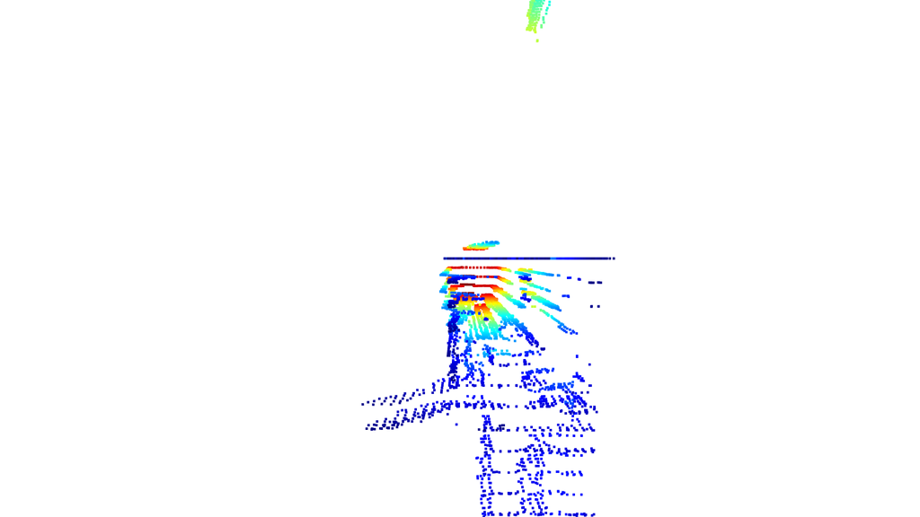

```python
display(Image(filename="test-converted/4-9-6-8.png"))
```

After some tweaking of the code and zooming out, the second image looks more promising. This is from the .laz file of the towers in the 3D models. The towers we also see on the images above. However, in these images we cannot spot rust or anything like this. LiDAR works by sending out laser pulses and measuring how long they take to return, capturing precise 3D information about surfaces; the colors in the visualizations typically represent height or intensity, not actual surface color — for example, red might indicate higher points and blue lower ones, purely for visual contrast. These images may be good for structure-level anomaly detection or clustering similar surfaces, but not for the specific goal of detecting rust/paint cracks.

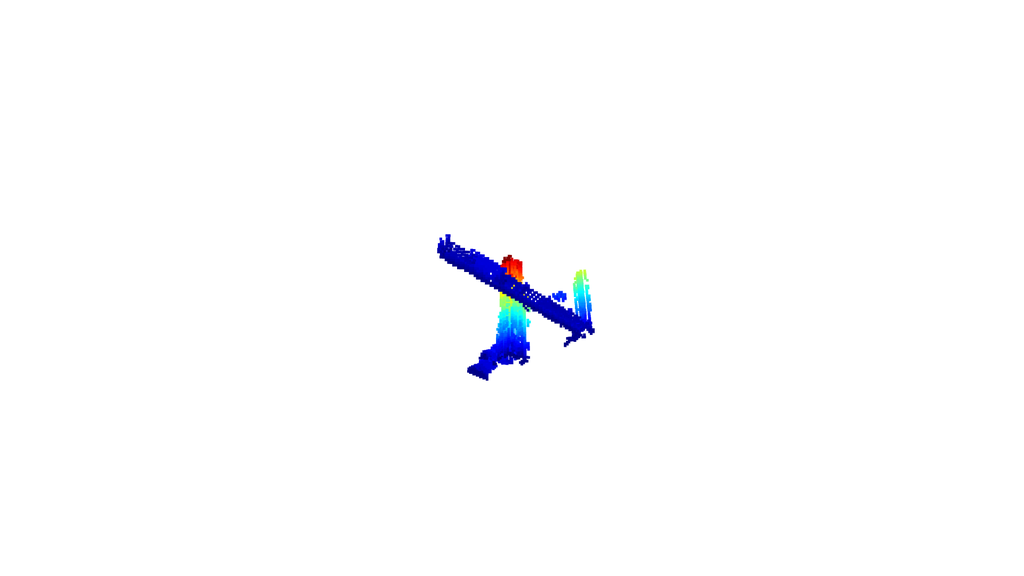

```python
display(Image(filename="test-converted/4-9-6-8-v2.png"))
```

## Conclusion

In this notebook, we explored the client's drone-acquired data through a combination of visual analysis, LiDAR rendering, and self-supervised feature learning. Due to download restrictions, only a small subset of ~50 images was manually collected. Despite this, we were able to extract meaningful insights.

We experimented with converting LiDAR .las files into 2D projections, which were helpful for understanding structural geometry but proved unsuitable for detecting small-scale surface anomalies such as rust or cracks. Instead, high-resolution drone images emerged as the most valuable source for fine-grained defect detection.

To organize and understand the image data without labels, we implemented a simple self-supervised learning approach using a modified ResNet-18. By training the model to produce similar embeddings for different augmented views of the same image, we generated useful feature representations. Clustering these embeddings revealed clear visual groupings—such as clean rooftops, cluttered areas, and industrial surfaces—demonstrating the potential of self-supervised learning for pre-labeling and anomaly detection in infrastructure monitoring.

These findings lay the groundwork for scaling up the dataset, refining the training process (e.g., using full SimCLR or BYOL), and ultimately detecting surface defects more reliably in real-world conditions.

All these methods could be more useful if a bulk download is available and we can get more images to try once again the self-supervised learning maybe with SimCLR and BYOL. The .laz files for now will be completely useless as they do not provide any details on the specific goal of this project. The manual labeling is of course useful but it would take a lot of time to be completed.

To conclude this notebook, I would say that this exploration was very useful and thorough. We explored all available data from the cloud including separetely downloaded images and the 3D files. We tried different techniques to end up with a dataset we can use. For now, the coclusion is that this data may be left aside only for validation and using open-source datasets for training. A way to continue with the client data could be to shoot images specifically for the task and manually label them.